# Relatório 03 - Distribuição de Probabilidade

Wagner Andrade

27/09/2024

# 1 Conjuntos

## 1.1 Introdução

A noção de conjunto, em Matemática, é a mesma da linguagem corrente, ou seja, conjunto é sinônimo de agrupamento, coleção, classe, etc. Os objetos que constituem determinado conjunto são chamados de elementos do conjunto. Se um elemento é constituinte de um conjunto significa que ele pertence ao conjunto. Esse fato é indicado pelo símbolo ∈ . Por exemplo, chamando de P o conjunto dos números pares, escrevemos: $2\in P$ e $3 \not\in P$.

## 1.2 Representação

Por enumeração do seus elementos: $A = \{4, 5, 6, 7, 8, 9, 10\}$;

Por uma propriedade que satisfaz todos os elementos do conjunto: $A = \{3\leq x \leq 10\}$.

Através de Diagrams:

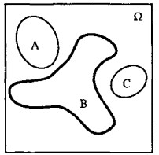

## 1.3 Conjunto vazio.

Chama-se vazio e indica-se por ∅ ou $\{\}$ o conjunto que não possue elemento algum.

## 1.4 Igualdade de Conjuntos.

Dois conjuntos, A e B, são iguais quando possuem os mesmos elementos.

## 1.5 Subconjunto.

Se **A** e **B** são dois conjuntos, pode ocorrer que todo elemento de **A** seja também elemento de **B**. Quando isso ocorrer, dizemos que **A** é subconjunto de **B** ou que **A** é parte de **B** ou, ainda, que **A** está contido em **B**.

**Notação:** $A \subset B$ {Lê-se: A está contido em B} ou $B \supset A$ {Lê-se: B contém A}.

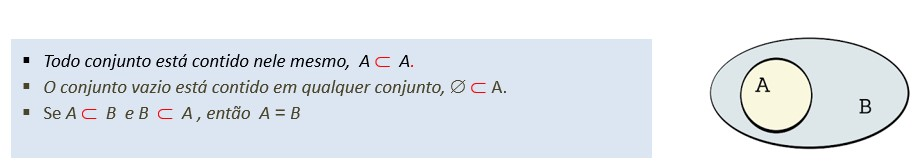

Se $A \subset B$ mas existe um elemento $b\in B$ tal que $b\notin A$, (b não pertence a A), diremos que $A$ é um subconjunto próprio de $B$.

## 1.6 Operações

### 1.6.1 União.

Dados dois conjuntos $A$ e $B$ indicaremos por $A\cup B$ O conjunto dos elementos que pertencem a $A$ ou a $B$, isto é, o conjunto dos elementos que pertencem a pelo menos um dos conjuntos “A” e “B”. Este conjunto é chamado de *união* de $A$ com $B$. Simbolicamente, $A \cup B = \{\omega \in \Omega\, |\, \omega \in A\; ou\; \omega \in B\}$.

A parte sombreada da Figura abaixo ilustra o conjunto $A \cup B$.

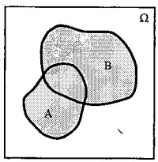

A união de três conjuntos A, B e C será representada por $A\;\cup\,B\,\cup\,C$.

$A\;\cup\;B\;\cup\;C = \{\omega\,\in\,\Omega\,|\,\omega\,\in\,A\:ou\:\omega\,\in B \;ou\;\;\omega \;\in C\}$

Mais geralmente, a união de **n** conjuntos $A_1 , A_2 , . . . , A_n$ é chamada analogamente e representada por $\bigcup_{i=1}^{n}A_i$.

### 1.6.2 Interseção.

Dados dois conjuntos **A** e **B**, definimos o conjunto **interseção** de **A** e **B** como o conjunto dos elementos que pertencem simultaneamente a **A** e a **B**, ou seja

$A\;\cap\;B \,=\;\{\omega\;\in\,\Omega\,|\,\omega\,\in\,A\;\;e\;\;\omega\,\in\,B\}$

A parte sombreada da figura abaixo ilustra a interseção de **A** e **B**.

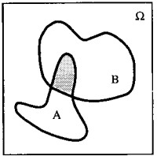

No caso de termos por exemplo três conjuntos **A**, **B** e **C**, a interseção é representada por $A\;\cap\;B\;\cap\;C$:

$A\;\cap\;B\;\;\cap\;C = \{\,\omega\,\in\,\Omega\,|\;\omega\,\in\,A\;\;e\;\;\omega\,\in\,B\;\;e\;\;\omega\,\in\,C\;\}$

A interseção de **n** conjuntos $A_1,\,A_2,\,...,A_n$ é representada por $\bigcap_{i=1}^{n}A_i$.

Dizemos que dois conjuntos **A** e **B** são **disjuntos** se $A\;\cap\;B = \emptyset$. Quando temos mais de dois conjuntos, dizemos que eles são disjuntos quando forem disjuntos tomados 2 a 2. A figura abaixo ilustra o caso de três conjuntos disjuntos.

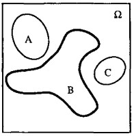

### 1.6.3 Complementar.

Dados um conjunto **A**. chamaremos *conjunto conplementar* de **A** o conjunto dos elementos de $\Omega$ que não pertencem a **A**. Simbolicamente

$A^C$ = $\{\;\omega\in\,\Omega\,|\;\omega\;\notin\;A\}$

A parte sombreada da figura abaixo indica o complementar de **A**.

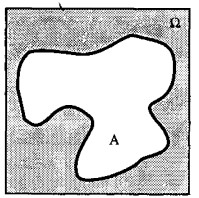

### 1.6.4 Diferença.

Dados dois conjuntos **A** e **B**. o conjunto

$A\;\cap B^C$ = $\{\;\omega\in\,\Omega\,|\;\omega\;\in\;A\;\;e\;\;\omega\notin B\}$ é chamado de *diferença de A e B*, é representado geralmente por *A - B*. A parte sombreada da figura abaixo mostra a diferença de *A e B*.

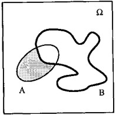

Se $B\subset A$, a diferença $A-B$ é chamada **diferença própria**.

## 1.7 Propriedades Importantes.

O Teorema a seguir lista as propriedades mais importantes que relacionam os conceitos definidos anteriormente.

**Teorema 1.**

1. Para todo conjunto $A\subset \Omega$, $A\cup\emptyset = A$, $A\cap\emptyset = \emptyset$.
2. $A\subset B$ se somente se $A\cup B = B$.
3. $A\subset B$ se somente se $A\cup B = A$.
4. $A\cup(B\cup C) = (A\cup B)\cup C$.
5. $A\cap(B\cap C) = (A\cap B)\cap C$.
6. $A\cap(B\cup C) = (A\cap B)\cup (A\cap C)$.
7. $A\cup(B\cap C) = (A\cup B)\cap (A\cup C)$.
8. $A\cup A^C = \Omega$, $\;$$A\cap A^C = \emptyset$,$\;$ $\emptyset^C =\Omega$, $\;$$\Omega^C =\emptyset$.
9. $(A^C)^C = A$;$\;$$A\subset B$ se somente $B^C\subset A^C$.
10. $(A \cup B\,)^C=A^C \cap B^C$.
11. $(A \cap B\,)^C=A^C \cup B^C$.

## 1.8 Partição.

Seja *A* um conjunto finito não vazio. Uma *partição de A* é uma família de conjuntos $A_1 , A_2, ...,A_k$, todos não vazios, e tais que:

1. $A_1\cup A_2\cup...\cup A_k = A$.
2. $A_i\cap A_j = \emptyset$ $\;$se $i\neq j$.

Ou seja, os conjuntos $A_1\cup A_2\cup...\cup A_k$ são disjuntos dois-a-dois e sua união é o conjunto *A*. Dizemos também que *A* foi *particionado* pelos conjuntos $A_1 , A_2, ...,A_k$.

# 2 Probabilidade

## 2.1 Conceitos Básicos

- **Experimento aleatório** é qualquer experimento cujo resultado não se consegue prever.
- **Espaço amostral** é o conjunto de todos os resultados possíveis de um experimento aleatório.
- **Evento** é um subconjunto qualquer do espaço amostral.
- **Espaço de Probabilidade**:

Dado o espaço amostral $\Omega$ de certo experimento aleatório, uma *Probabilidade* é uma função que atribui a cada evento $E \subset \Omega$ um determinado valor P(A) que satifaz as seguintes condições:

1. $0 \leq PA) \leq 1$, para todo evento $A \subset \Omega$;
2. $P(\emptyset) = 0$, $\,P(\Omega) = 1$;
3. Se *A* e *B* são eventos disjuntos (também chamados mutuamente exclusivos) $P(A\cup B) = P(A) + P(B)$.
- **Espaço Amostral Equiprovável** é quando as probabilidades dos eventos simples são todas iguais. Se o espaço amostral equiprovável possui *n* elementos, como a soma das probabilidades dos eventos simples correspondentes é igual a 1. podemos concluir que cada evento simples deve ter probabilidade igual a 1/n.

## 2.2 Principais Propriedades.

- $P(A^C) = 1 - P(A)$.
- Se $A\subset B$ então $P(A) = P(B) - P(B -A)$.
- $P(A\cup B) = P(A) + P(B) - P(A\cap B)$.

### 2.2.1 Exemplos e Aplicações.

1. Sejam A e B eventos tais que $P(A) = \frac{1}{2}\; , P(B) = \frac{1}{4}\;, P(A\cap B) = \frac{1}{5}$.

Calcular:

a) $P(A\cup B)$;

b) $P(A^C)$;

c) $P(B^C)$;

d) $P(A\cap B^C)$;

e) $P(A^C\cap B)$;

f) $P(A^C\cap B^C)$;

g) $P(A^C\cup B^C)$;

*Soluções*:

a) $P(A\cup B) = P(A) + P(B) - P(A\cap B)$

$P(A\cup B) = \frac{1}{2} + \frac{1}{4} - \frac{1}{5} = \frac{10+5-4}{20} = \frac{11}{20}$

b) $P(A^C) = 1 - P(A) = 1 - \frac{1}{2} = \frac{1}{2}$.

c) $P(B^C) = 1 - P(B) = 1 - \frac{1}{4} = \frac{3}{4}$.

d) $P(A\cap B^C) = P(A) - P(A\cap B) = \frac{1}{2} - \frac{1}{5} = \frac{5-2}{10} = \frac{3}{10}$.

e) $P(A^C\cap B) = P(B) - P(A\cap B) = \frac{1}{4} - \frac{1}{5} = \frac{5-4}{20} = \frac{1}{20}$.

f) $P(A^C\cap B^C) = 1 - P[(A\cup B)^C] = 1 - \frac{11}{20} = \frac{20-11}{10} = \frac{9}{20}$.

g) $P(A^C\cup B^C) = 1 - P[(A\cap B) = 1 - \frac{1}{5} = \frac{4}{5}$.

2) Uma caixa contém 20 peças em boas condições e 15 em más condições. Uma amostra de de 10 peças é extraída. Calcular a probabilidade de que ao menos uma peça na amostra seja defeituosa.

*Solução;*

Sejam:

Variável aleatória (X) = Quantidade de peças extraídas= 10;

A variável aleatória (X) pode assumir os valores: 0, 1, 2,.., 10;

Vamos atribuir o valor $0$ para o sucesso (Peças defeituosas) e $1$ para o sucesso ( peças sem defeitos). Temos que,

$P(0)$ = $\frac{15}{35} = \frac{3}{7}$.

$P(1)$ = $\frac{20}{35} = \frac{4}{7}$.

$P(X= 0)$, significa a probabilidade de termos nenhuma peça com defeito;

$P(X=1)$, significa a probabilidade de termos $1$ peça com defeito;

$P(X=2)$, significa a probabilidade de termos $2$ peças com defeito;

……………………………………………………………………..;

$P(X=10)$, significa a probabilidade de termos (10) peças com defeito;

A probabilidade para que tenhamos, exatamente, nenhuma, uma, duas,…, dez peças defeituosas é dada pela expressão:

$\binom{n}{k}p^k(1-p)^{n-k}$, onde *p* é a probabilidade do fracasso, isto é, peças defeituosas.

Para exatamente 4 peças defeituosas, a probabilidade é:

$\binom{10}{4}{(\frac{3}{7}})^4(\frac{4}{7})^{6} = 0,24665$.

Na tabela abaixo estão todas as probabilidades para as peças defeituosas, considerando exatamente 0,1,2, . . ..

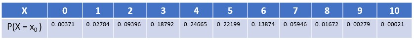

É claro que para resolver o nosso problema não precisava de tudo isso.

Basta calcularmos $P(X\geq 1)= 1- P(X = 0) = 1 - 0,00371 = 0,9963$.

3) (Pôquer com dados) Cinco dados são jogados simultaneamente e os resultados são classificados em:

$A_1 =$ todos diferentes;

$A_2 =$ um par;

$A_3 =$ dois pares;

$A_4 =$ três iguais;

$A_5 =$ full (três iguais e dois iguais);

$A_6 =$ quatro iguais (pôquer);

$A_7 =$ cinco iguais;

$A_8 =$ uma sequência.

## 2.3 Probabilidades Condicionais.

Dados dois eventos *A* e *B*, a *probabilidade condicional* de *B* dado *A* é o número $P(A\cap B) / P(A)$. Representaremos este número pelo símbolo $P(B/A)$. Temos então simbolicamente

$P(B/A) = \frac{P(A\cap\, B)}{P(A)}$.

### 2.3.1 Exemplos e Aplicações.

1) Um grupo de pessoas está classificado da seguinte forma:

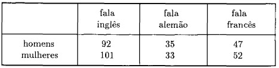

Escolhe-se uma pessoa ao acaso. Sabendo-se que essa pessoa fala francês, qual é a probabilidade de que seja homem?

*Solução*

Seja *A* o evento que ocorre se a pessoa escolhida fala francês e *B* se a pessoa escolhida é homem. Temos,

$P(A) = \frac{47 + 52}{360} = \frac{99}{360}$,

$P(A\cap B) = \frac{47}{360}$,

e portanto

$P(A/B) = \frac{P(A\cap B)}{P(A)} = \frac{47/360}{99/360} = \frac{47}{99}$.

2) Sabe-se que 80% dos pênaltis marcados a favor do Brasil são cobrados por jogadores do Flamengo. A probabilidade de um pênalti ser convertido é de 40% se o cobrador for do Flarnengo e de 70% em caso contrário. Um pênalti a favor do Brasil acabou de ser marcado:

a) Qual a probabilidade do pênalti ser cobrado por um jogador do Flamengo e ser convertido?

*Solução*

a) A probabilidade deseja é:

P(“cobrador é do Flamengo” e “Pênalti é convertido”) = $P(F\cap C)$.

Pelo Teorema do Produto:

$P(F\cap C) = P(F) \cap P(C/F) = 0,8\;\cdot\;0,4 = 0,32.$.

b) Qual a probabilidade do pênalti ser convertido?

*Solução*

Note que, do enunciado, apenas sabemos as probabilidades condicionais do pênalti ser convertido, dado que o batedor seja do Flamengo ou pertença a um outro clube. Para fazer uso dessas probabilidades condicionais, decompomos o evento C:

“o pênalti é convertido”

na união de dois eventos disjuntos:

“o cobrador é do Flamengo e o pênalti é convertido” e “o cobrador não é do Flamengo e o pênalti é convertido”. Isto é:

$C = (F\cap C) \;\cup\;(F^C\;\cap\;C)$. Logo

$P(C) = P(F\cap C) \;+\;P(F^C\;\cap\;C)$.

Cada uma das probabilidade do lado direito pode ser calculada com auxilio do Teorema do Produto.

$P(F\;\cap C) = P(F)\;\cdot\;P(C/F) = 0,8\;\cdot\;0,4 = 0,32.$

$P(F^C\;\cap C) = P(F^C)\;\cdot\;P(C/F^C) = 0,2\;\cdot\;0,7 = 0,14.$ Logo

$P(C) = 0,32\; +\;0,14 = 0,46.$

## 2.4 Probabilidade de Bayes.

**(Teorema da Probabilidade Total)**

Se *B* é um evento contido numa união de eventos disjuntos $A_1, A_2, ..., A_n$ e $P(A_1)>0$ , $P(A_2)>0$ ,…, $P(A_n)>0$ , então

$P(B) = P(A_1)P(B/A_1) + P(A_2)P(B/A_2) + . . .+ P(A_n)P(B/A_n)$.

**(Teorema de Bayes)**

Nas condições do Teorma da Probabilidade Total, Se $P(B) > 0$, então, para $i$, $i = 1, 2, ..., n$,

$P(A_i/B) = \frac{P(A_i)\,\cdot P(B/A_i)}{P(A_1)P(B/A_1) + P(A_2)P(B/A_2) + . . .+ P(A_n)P(B/A_n)}$

### 2.4.1 Exemplos e Aplicações.

1) Durante o mês de agosto a probabilidade de chuva em um dia determinado é de 4/10. O Fluminense ganha um jogo em um dia com chuva com probabilidade 6/10 e em um dia sem chuva com probabilidade de 4/10. Sabendo-se que o Fluminense ganhou um jogo naquele dia de agosto, qual a probabilidade de que choveu nesse dia?

*Solução*

2) Num exame há 3 respostas para cada pergunta e apenas uma delas é certa. Portanto, para cada pergunta, um aluno tem probabilidade 1/3 de escolher a resposta certa se ele está adivinhando e 1 se sabe a resposta. Um estudante sabe 30% das resposta do exame. Se ele deu a resposta correta para uma das perguntas, qual é a probabilidade de que a adivinhou?

*Solução*

Utilizando o Teorema de Bayes, temos

$P(adivinhou\;/\;resposta\,correta) = \frac{0,70\;\frac{1}{3}\cdot}{0,70\;\cdot\;\frac{1}{3}\;+\;0,30\;\cdot\;1} = \frac{7}{16}$.

## 2.5 A Distribuição Binomial.

*O problema que queremos resolver é o seguinte: Qual é a probabilidade de obtemos k sucessos em n provas?*

A probabilidade de nessas n provas obtermos k sucessos e, em consequência, n - k fracassos em uma ordem pré-determinada, por exemplo, os sucessos na k primeiras provas e os fracassos nas demais:

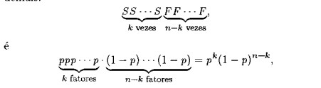

pois as provas são independentes.

**Teorema Binomial:**

A probabilidade de ocorrerem exatamente k sucessos em sequência de n provas independentes, na quala probabilidade de sucesso em cada prova é p, é igual a

$\binom{n}{k}p^k(1-p)^{n-k}$

### 2.5.1 Exemplos e Aplicações.

1) Jogamos uma moeda não viciada 10 vezes. Qual é a probabilidade de obtermos exatamente 5 caras?

*Solução:*

Pondo sucesso = cara, temos p = 1/2 em cada prova e as provas são independentes. Queremos achar a probabilidade de k = 5 sucessos em n = 10 provas. Pelo teorema binomial, a rsposta é

$\binom{10}{5}{(\frac{1}{2}})^k(1-{\frac{1}{2}})^{5} = \frac{252}{1024} = \frac{63}{256}$.

2) Um aluno marca ao acaso as respostas em um teste múltipla-escolha com 10 questões e cinco alternativas por questão. Qual é a probabilidade dele acertar exatamente 4 questões?

*Solução:*

Pondo sucesso = acerto, temos p = 1/5 em cada prova, e as provas são independentes.

A probabilidade dele acertar exatamente k = 4 questões é

$p_k = \binom{10}{4}{(\frac{1}{5}})^4(1-{\frac{1}{5}})^{6} = \frac{172 032}{1 953 125}\approx 0,088$.